# Week 11 Live Session - Selected Answers

w203 Instructional Team

March 20, 2017

## Multiple linear regression (MLR)

A simple linear regression uses a single predictor variable (X) to model the response variable (Y). In the real world, relationships are often more complex and more than one factor can influence the outcome of an event (i.e. the response variable). A multiple linear regression describes how a single response variable Y depends linearly on a number of predictor variables.

For example, a single linear regression can be used to show the impact of location on housing prices. A multiple linear regression can also factor in other factors that may have a stronger impact on the price, such as the number of bathrooms, number bedrooms, the number of bathrooms, the year the house was built, the square footage, etc.

We will use the term multiple regression for models with two or more predictors and one response (There are also regression models with two or more response variables, which are called multivariate regression models).

### Interpreting coefficients in multiple regression correctly

Coefficients in a multiple regression have a ceteris paribus interpretation - holding all other independent variables (and the error) constant.

In the example
$$\hat{y} = 1 + 2x_1 + 3x_2$$
It is not accurate to say “For each change of 1 unit in $x_1$, $y$ changes 2 units”. What is correct is to say, “If $x_2$ is fixed, then for each change of 1 unit in $x_1$, the conditional mean of $y|x$ changes 2 units.”

Q1.1: Give an example of variables $y, x_1,$ and $x_2$, such that the coefficient on $x_1$ is likely to be positive in a simple regression, but drops to zero or negative when $x_2$ is added.

One idea is that $x_1$ is a distant cause of y, but $x_2$ is a much more proximate cause of y. Say we’re predicting an individual’s salary and $x_1$ is parents’ years of education, which is likely to have a positive relationship. If $x_2$ is the individual’s years of education, this probably matters more for wage. Holding an individual’s education constant, parents’ years of education may not matter much at all.

Another idea: Suppose we study wage in an industry where experience is the main driver of wage. Say $x_1$ is years of education, which has a weak positive relationship with wage. However, say we add $x_2$, representing the individual’s age. Holding age constant, if one individual has more years of education, they will likely have fewer years of work experience, so the coefficient for years of education may become negative.

# ———–

## OLS Estimators

Remember that a regression coefficient based on sample data is an estimate of a true regression parameter for the population the sample is drawn from. There are several desireable properties that we might want our coefficients to have. These properties require different sets of assumptions to hold.

Q2.1: What does it mean for an estimator to be unbiased?

An estimator is unbiased if its expected value is the same as the true parameter value in the population.

Q2.2: What does it mean for an estimator to be consistent?

An estimator of a parameter is consistent if the estimate converges to the true value of the parameter in the limit (probability limit) as the sample size increases. I.e. its accuracy tends to improve as the sample size grows larger.

Q2.3: What does it mean for an estimator to be efficient?

Efficiency refers to the variance of the estimator. Since the estimator is a random variable, its value will be different depending on what sample is drawn, and we want an estimator that varies less across different samples.

Q2.4: What other properties might we want our OLS coefficients to have?

We will also want to know the sampling distribution of our statistics so we can test hypotheses, construct confidence intervals, and so forth. In particular, it will be very useful if our coefficients have a normal sampling distribution.

# ———–

To show that the coefficients in a multiple regression are unbiased, we need four assumptions, which are extension of the assumptions we learned for simple regression.

Q3.1: What are these four assumptions? 1. Linear in Parameters 2. Random Sampling 3. No Perfect Collinearity 4. Zero Conditional Mean

Q3.2: What are the implications of these four assumptions, both conceptually and mathematically?

# Associative versus Causal models

Q4.1 What is the difference between the following two conditions?

1. $cov(x, \hat{u}) = 0$
2. $cov(x, u) = 0$

The first condition is the sample moment condition, which is always true for an ols regression. It’s a mathematical consequence of minimizing least squares. The second condition refers to the population model, and it’s what we call exogeneity. This might or might not be true. In particular, if there is an omitted variable that’s correlated with x, exogeneity will not hold.

### Associative models

An associative model means that we don’t care about causality. We just want to estimate the line of best fit in the population. This is the line that best fits the joint distribution of X and Y.

This makes life easy, because if we define our errors as the distance from this line, we would find that they fulfill $cov(x, u) = 0$. This condition is exactly the same as the exogeneity condition (CLM 4*). This means that as long as we also fulfill CLM 1-3, OLS will estimate this line *consistently*.

Q4.3 Suppose you collect a set of observations from this population model and fit an ols regression line to it. How does this line compare to the line above? Which of the two conditions from Q4.1 does this line fulfill?

Since we’re moving to a sample, our line will be a little bit different from the population best fit line. By the mechanics of ols regression, we know this line will fulfill $cov(x, \hat{u}) = 0$.

### Causal models

Causal modeling is a huge topic and we will explain just a little about how we think about it intuitively. Note that the Wooldridge text generally takes a causal approach to modeling.

$$rainfall = 0 \cdot umbrellas + 20 \cdot humidity - 10 \cdot airpressure + u$$

where u is uncorrelated with all other predictor variables. This model tells us that buying an extra umbrella has zero effect on rainfall.

The line would have to be perfectly flat, since the partial derivative of rainfall with respect to umbrellas is zero.

Q4.5 Assuming that we haven’t measured humidity or airpressure, can OLS regression estimate this line?

No, ols regression can only estimate the population best fit line, but the causal line we have is clearly different.

Since we didn’t measure humidity or airpressure, they become part of the error in our simple regression. A causal modeler would then say that umbrellas is correlated with the error - this is a condition known as *endogeneity*.

## Model Diagnostics

Model diagnostic procedures, both graphical methods and formal statistical tests, are important for checking our model. These procedures allow us to explore whether the assumptions of the regression model are valid and decide whether we can trust subsequent inference results.

What is the value in examining a scatter plot for a regression analysis?

### Residuals Plots

A residuals plot can be used to assess the assumption that the variables have a linear relationship. The plot is formed by graphing the standardized residuals on the y-axis and the standardized predicted values on the x-axis. An optional horizontal line can be added to aid in interpreting the output.

### Influential Observations

Q4.1 What does it mean for a data point to have high leverage?

Q4.2 What does it mean for a data point to have high influence?

Q4.3 How is it possible for a data point to have low leverage but high influence?

Q4.4 How is it possible for an outlier to have low influence?

# R Exercise

The file crime1.RData contains individual-level data on criminal activity and punishment. It was used in the paper, J. Grogger (1991), âCertainty vs. Severity of Punishment,â Economic Inquiry 29, 297-309.

```r
load("crime1.RData")
desc
```

```
##    variable                           label
## 1    narr86          # times arrested, 1986
## 2   nfarr86          # felony arrests, 1986
## 3   nparr86      # property crme arr., 1986
## 4      pcnv proportion of prior convictions
## 5    avgsen       avg sentence length, mos.
## 6   tottime  time in prison since 18 (mos.)
## 7   ptime86      mos. in prison during 1986
## 8    qemp86       # quarters employed, 1986
## 9     inc86       legal income, 1986, $100s
## 10    durat           recent unemp duration
## 11    black                     =1 if black
## 12   hispan                  =1 if Hispanic
## 13   born60              =1 if born in 1960
## 14   pcnvsq                          pcnv^2
## 15   pt86sq                       ptime86^2
## 16  inc86sq                         inc86^2
```

1. First, you are interested in the simple regression of narr86 on pcnv. Examine these variables and run a linear regression.

```r
plot(data$pcnv, data$narr86)
model1 = lm(narr86 ~ pcnv, data = data)
model1
```

```
##
## Call:
## lm(formula = narr86 ~ pcnv, data = data)
##
## Coefficients:
## (Intercept)         pcnv
##      0.4608      -0.1575
```

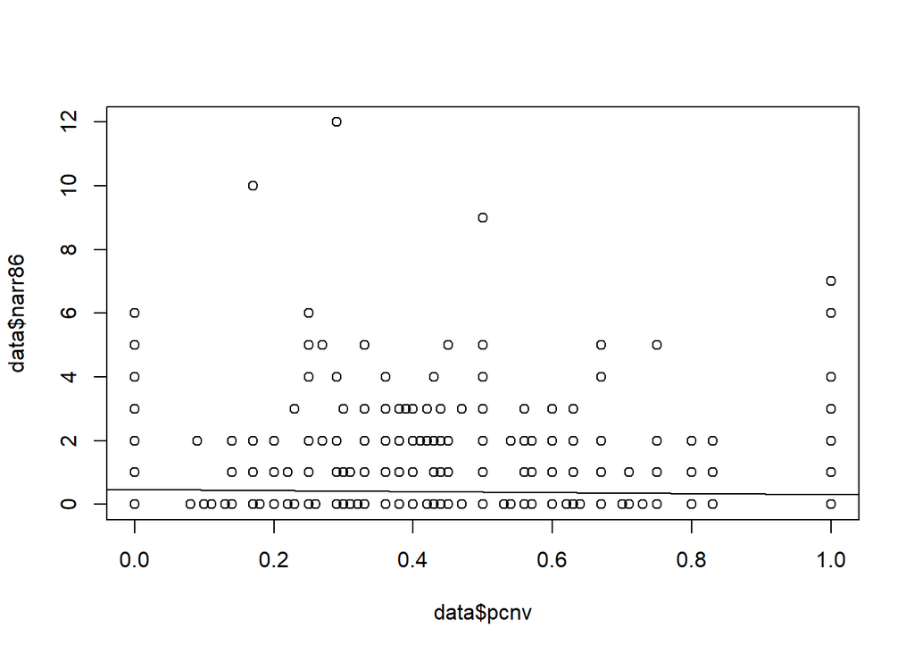

```r
abline(model1)
```

2. Generate a residuals vs. fitted values plot. Assess the assumptions for unbiasedness of OLS.

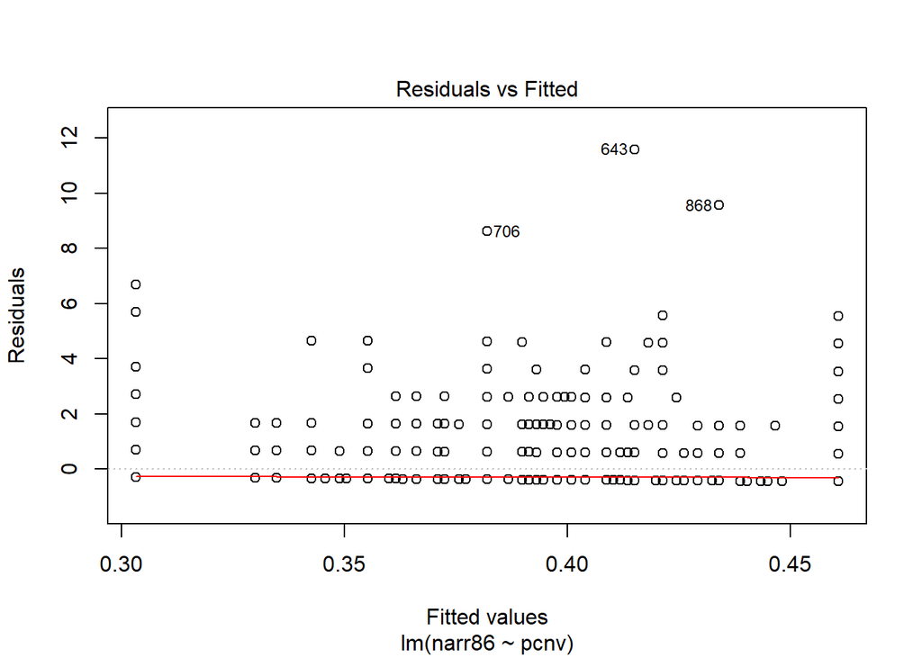

```r
plot(model1, which =1)
```

3. Generate a residuals vs. leverage plot. Assess whether any observations are exerting unusual influence on the regression coefficient.

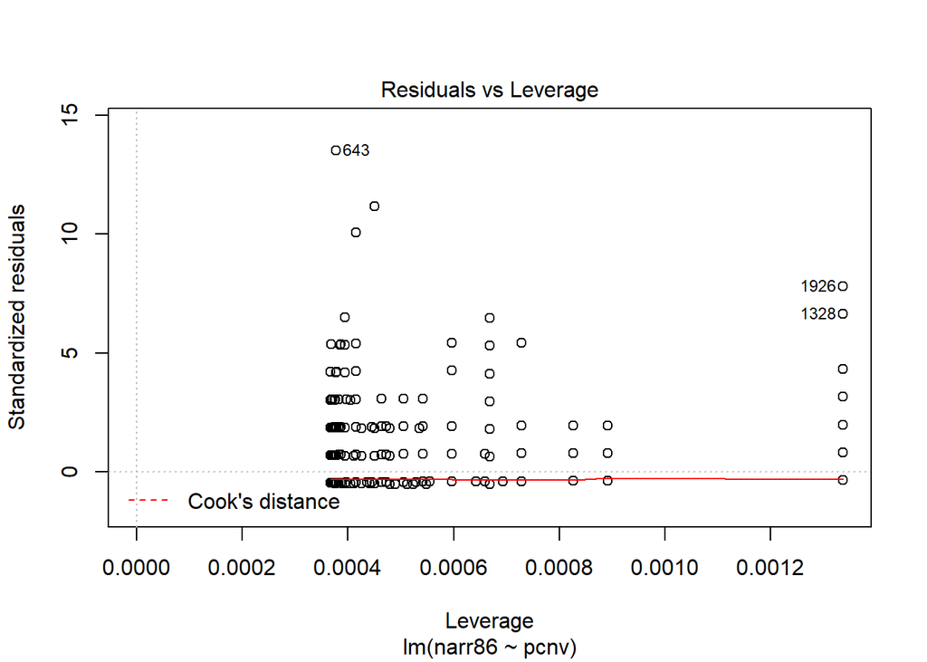

```r
plot(model1, which =5)
```

4. Interpret your regression coefficients.
5. Next, you are interested in adding variable avgsen to your model. However, instead of fitting a linear model directly in R, use the regression anatomy formula to predict what the slope coefficient for avgsen would be in the multiple regression.

Recall that the coefficient on an independent variable $x_i$ is equal to,

$$\beta_i = cov(y, r_i) / var(r_i)$$

where $r_i$ is the residual from regressing $x_i$ on all other independent variables.

- First, regress avgsen on pcnv and extract the residuals from this regression.

```r
plot(data$pcnv, data$avgsen)
fs = lm(avgsen ~ pcnv, data = data)
fs
```

```
##
## Call:
## lm(formula = avgsen ~ pcnv, data = data)
##
## Coefficients:
## (Intercept)         pcnv
##      0.5502       0.2293
```

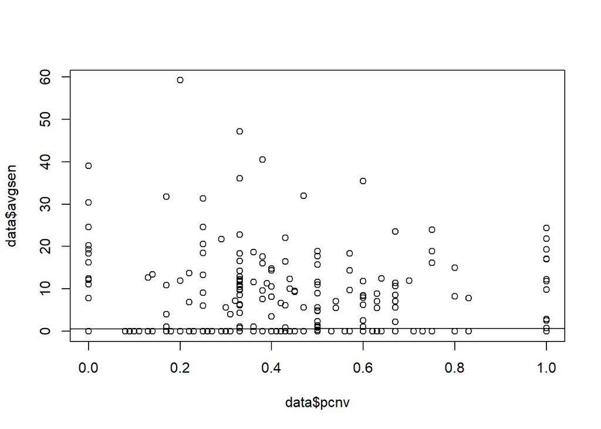

```r
abline(fs)
```

- Next, regress narr86 on the residuals from your first stage. What slope coefficient do you get?

```r
ra = lm(data$narr86 ~ fs$resid)
ra
```

```
##
## Call:
## lm(formula = data$narr86 ~ fs$resid)
##
## Coefficients:
## (Intercept)     fs$resid
##    0.404404     0.007638
```

6. Now, confirm your previous result by directly fitting the multiple regression model. That is, run the regression of narr86 on both pcnv and avgsen. What is the coefficient on avgsen?

```r
model2 = lm(narr86 ~ pcnv + avgsen, data = data)
model2
```

```
##
## Call:
## lm(formula = narr86 ~ pcnv + avgsen, data = data)
##
## Coefficients:
## (Intercept)         pcnv       avgsen
##    0.456558    -0.159268     0.007638
```

7. Comment on the practical significance of your results.
8. How do you explain the sign of the coefficient on avgsen? Explain whether this variable is exogenous. Can your coefficient have a causal interpretation?
9. Use R to predict what number of arrests an individual would have, if half of their prior arrests led to convictions and their average sentence was 3 months.

```r
predictmodel <- data.frame(pcnv=.5,  avgsen=3)
predict(model2,predictmodel)
```

```
##         1
## 0.3998387
```

10. Which of your regression models fits the data better? Provide statistics to back up your response.

```r
AIC(model1)
```

```
## [1] 6896.031
```

```r
AIC(model2)
```

```
## [1] 6895.366
```

11. Place the results from both models in a regression table.

### Cheat Sheet for checking bias assumptions

Linear population model: Nothing to check, because we haven’t constrained the errors yet.

Random Sampling: Not interpretable from graphs. You need information about where the data comes from.

No perfect multicollinearity: This is a rare case that will trigger an error in R.

Zero-conditional mean: Check the Residual vs Fitted plot for a systematic depature from the horizontal line.